# Preprocessing

## Import Packages and Data

```python
from transformers import AutoTokenizer, AutoModelForSequenceClassification, pipeline
import torch
import pandas as pd
import numpy as np
import seaborn as sns
import matplotlib.pyplot as plt
from sklearn.metrics import accuracy_score, precision_recall_fscore_support, confusion_matrix, classification_report
# Set global font settings to Times New Roman, size 12
plt.rcParams["font.family"] = "Times New Roman"
plt.rcParams["font.size"] = 12
```

```python
df = pd.read_csv("reviews_clean.csv")
```

```python
df.head()
```

|  | Rating | Parent Asin | Main Category | Product Title | Retailer | Review | Word Count | Sentence Count |
| --- | --- | --- | --- | --- | --- | --- | --- | --- |
| 0 | 1 | B0BR5N8Y3M | Grocery | Gumballs for Gumball Machine - 1 Inch Large Gu... | Global Gumball | What the ? I normally am happy with this produ... | 66 | 4 |
| 1 | 1 | B00I8GLPSO | Grocery | Stove Top Stuffing Mix, Chicken, 12 Ounce Box | Stove Top | It can often be purchased for less money at an... | 36 | 2 |
| 2 | 1 | B000JMFCXO | Grocery | Almonds Whole Natural 2lb (32 Ounces) | Spicy World | Inedible outrage. Lots of variability w/ this ... | 67 | 10 |
| 3 | 1 | B0C4FMN1QK | Grocery | Knorr Pasta Sides For Delicious Quick Pasta Si... | Knorr | Cheap and easy. These are cheap and easy side ... | 27 | 4 |
| 4 | 1 | B00ICT8RQU | Grocery | Trader Joe's Instant Coffee Packets with Cream... | TJ's | Two thumbs down. Not impressed, still needed t... | 17 | 3 |

## Emojis Analysis

```python
import emoji

# Function to detect if any emojis are present
def contains_emoji(text):
    return any(char in emoji.EMOJI_DATA for char in str(text))

# Apply to your DataFrame
df['contains_emoji'] = df['Review'].apply(contains_emoji)
```

```python
# Total number of reviews
total_reviews = len(df)

# Number of reviews that contain emojis
emoji_reviews = df['contains_emoji'].sum()

# Percentage
emoji_percentage = (emoji_reviews / total_reviews) * 100

# Display result
print(f"{emoji_percentage:.2f}% of reviews contain emojis.")
```

```
1.76% of reviews contain emojis.
```

```python
# Function to remove emojis from text
def remove_emojis(text):
    return ''.join(char for char in str(text) if char not in emoji.EMOJI_DATA)

# Apply to remove emojis
df['Review'] = df['Review'].apply(remove_emojis)
df = df.drop(columns=['contains_emoji'])
```

## Sentiment Score

```python
tokenizer = AutoTokenizer.from_pretrained("nlptown/bert-base-multilingual-uncased-sentiment")

model = AutoModelForSequenceClassification.from_pretrained("nlptown/bert-base-multilingual-uncased-sentiment")
```

```python
def sentiment_score(text):
    tokens = tokenizer.encode(text, return_tensors='pt', truncation=True, padding=True)
    result = model(tokens)
    return int(torch.argmax(result.logits))+1
```

```python
# Apply to DataFrame
df['Sentiment Score'] = df['Review'].apply(sentiment_score)

# Add topics to reviews to see if the sentiment prediction is better
# df[['Review', 'main_category']].apply(Sentiment Score, axis=1)
```

```python
print(df[['Review', 'Rating', 'Sentiment Score']].tail())
```

```
                                                 Review  Rating  \
2495  Great buy for peanut butter M&M lovers. This i...       5
2496  Best Red Beans EVER. A Louisiana friend of min...       5
2497  A must have for cooking. If you love oriental ...       5
2498  Easy to Use. I can't tell if this boosts my en...       5
2499  Sweeter than other mirin I've tried before. I ...       5

      Sentiment Score
2495                5
2496                5
2497                5
2498                4
2499                5
```

## Confusion Matrix & Performance Metrics

Compare predicted sentiment with star Ratings serving as a proxy for ground truth sentiment labels using accuracy, precision, recall, F1-score, and confusion matrix.

```python
y_true = df['Rating']
y_pred = df['Sentiment Score']

conf_mat = confusion_matrix(y_true, y_pred, labels=[1,2,3,4,5])
```

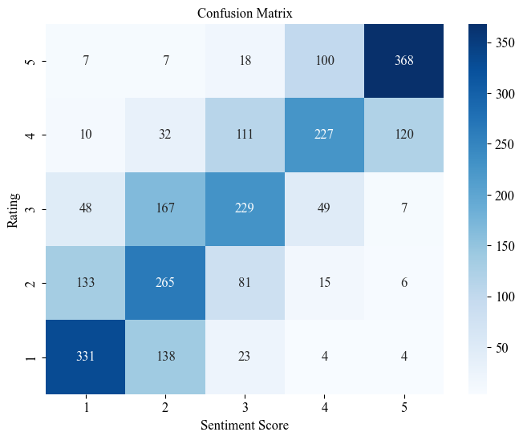

```python
plt.figure(figsize=(8, 6))

sns.heatmap(conf_mat,
            annot=True,
            fmt='d',
            cmap='Blues',
            xticklabels=[1,2,3,4,5],
            yticklabels=[1,2,3,4,5],
            annot_kws={"size": 12, "fontname": "Times New Roman"})  # numbers inside boxes

plt.gca().invert_yaxis()

plt.xlabel('Sentiment Score', fontsize=12, fontname='Times New Roman')
plt.ylabel('Rating', fontsize=12, fontname='Times New Roman')
plt.title('Confusion Matrix', fontsize=12, fontname='Times New Roman')

plt.xticks(fontsize=12, fontname='Times New Roman')
plt.yticks(fontsize=12, fontname='Times New Roman')

plt.show()
```

```python
accuracy = accuracy_score(y_true, y_pred)

precision, recall, f1, _ = precision_recall_fscore_support(y_true, y_pred, labels=[1,2,3,4,5], average=None)

conf_mat = confusion_matrix(y_true, y_pred, labels=[1,2,3,4,5])

report = classification_report(y_true, y_pred, labels=[1,2,3,4,5])
```

```python
# Accuracy
accuracy = accuracy_score(y_true, y_pred)

# Detailed metrics
precision, recall, f1, support = precision_recall_fscore_support(y_true, y_pred, labels=[1,2,3,4,5], average=None)

# Overall metrics
macro_precision, macro_recall, macro_f1, _ = precision_recall_fscore_support(y_true, y_pred, average='macro')
micro_precision, micro_recall, micro_f1, _ = precision_recall_fscore_support(y_true, y_pred, average='micro')
weighted_precision, weighted_recall, weighted_f1, _ = precision_recall_fscore_support(y_true, y_pred, average='weighted')

# Report
print(f"Accuracy: {accuracy:.4f}\n")

print("Precision, Recall, F1 by class:")
for i, label in enumerate([1, 2, 3, 4, 5]):
    print(f"{label} stars → Precision: {precision[i]:.4f}, Recall: {recall[i]:.4f}, F1: {f1[i]:.4f}")

print("\nOverall metrics:")
print(f"Macro  → Precision: {macro_precision:.4f}, Recall: {macro_recall:.4f}, F1: {macro_f1:.4f}")
print(f"Micro  → Precision: {micro_precision:.4f}, Recall: {micro_recall:.4f}, F1: {micro_f1:.4f}")
print(f"Weighted → Precision: {weighted_precision:.4f}, Recall: {weighted_recall:.4f}, F1: {weighted_f1:.4f}")

print("\nConfusion Matrix:")
print(pd.DataFrame(conf_mat, index=[f"True {i}" for i in [1,2,3,4,5]], columns=[f"Pred {i}" for i in [1,2,3,4,5]]))

# Optional: print scikit-learn’s full classification report
print("\nClassification Report:")
print(classification_report(y_true, y_pred, labels=[1,2,3,4,5]))
```

```
Accuracy: 0.5680

Precision, Recall, F1 by class:
1 stars → Precision: 0.6257, Recall: 0.6620, F1: 0.6433
2 stars → Precision: 0.4351, Recall: 0.5300, F1: 0.4779
3 stars → Precision: 0.4957, Recall: 0.4580, F1: 0.4761
4 stars → Precision: 0.5747, Recall: 0.4540, F1: 0.5073
5 stars → Precision: 0.7287, Recall: 0.7360, F1: 0.7323

Overall metrics:
Macro  → Precision: 0.5720, Recall: 0.5680, F1: 0.5674
Micro  → Precision: 0.5680, Recall: 0.5680, F1: 0.5680
Weighted → Precision: 0.5720, Recall: 0.5680, F1: 0.5674

Confusion Matrix:
        Pred 1  Pred 2  Pred 3  Pred 4  Pred 5
True 1     331     138      23       4       4
True 2     133     265      81      15       6
True 3      48     167     229      49       7
True 4      10      32     111     227     120
True 5       7       7      18     100     368

Classification Report:
              precision    recall  f1-score   support

           1       0.63      0.66      0.64       500
           2       0.44      0.53      0.48       500
           3       0.50      0.46      0.48       500
           4       0.57      0.45      0.51       500
           5       0.73      0.74      0.73       500

    accuracy                           0.57      2500
   macro avg       0.57      0.57      0.57      2500
weighted avg       0.57      0.57      0.57      2500
```

```python
from scipy.stats import wilcoxon
stat, p = wilcoxon(y_pred - y_true)
print(f"Wilcoxon signed-rank test: p = {p:.4f}")
```

```
Wilcoxon signed-rank test: p = 0.0000
```

```python
from sklearn.metrics import confusion_matrix
from scipy.stats import chi2_contingency

cm = confusion_matrix(y_true, y_pred, labels=[1,2,3,4,5])
stat, p, dof, expected = chi2_contingency(cm)
print(f"Chi-square test: p = {p:.4f}")
```

```
Chi-square test: p = 0.0000
```

```python
from sklearn.metrics import mean_absolute_error
mae = mean_absolute_error(y_true, y_pred)
print(f"MAE: {mae:.2f}")
```

```
MAE: 0.52
```

Although both the Wilcoxon signed-rank test and the Chi-square test on the confusion matrix indicate a statistically significant difference between predicted and actual sentiment Ratings (p < 0.001), the mean absolute error (MAE) is 0.52, suggesting that the magnitude of mismatch is small in practical terms. This implies that the model’s predictions are typically within one star of the true Rating, which may be acceptable depending on the application. Therefore, while the model is not perfectly aligned with the proxy labels, its performance may still be considered strong from a business or user experience perspective.

```python
# Calculate off-by-one accuracy
off_by_one = np.abs(y_true - y_pred) <= 1
off_by_one_accuracy = np.mean(off_by_one)

print(f"Off-by-one accuracy: {off_by_one_accuracy:.4f}")
```

```
Off-by-one accuracy: 0.9276
```

Importantly, when allowing for a tolerance of ±1 star, the off-by-one accuracy rises substantially to 0.9276. This means that in over 92% of cases, the model’s predicted sentiment was either exactly correct or differed from the user-provided rating by only a single star. This result is consistent with the performance reported by the developers of the nlptown/bert-base-multilingual-uncased-sentiment model, who observed 67% exact accuracy and 95% off-by-one accuracy on held-out English reviews. The high off-by-one accuracy underscores that most misclassifications occur between neighbouring ratings, as also reflected in the confusion matrix. Such small discrepancies are unsurprising, noting that user-generated star ratings, while serving as proxy sentiment labels, may not always represent consistent or objective sentiment. Such Ratings can be influenced by transient emotions, rating behaviour biases, or factors unrelated to textual sentiment (e.g., delivery issues, prior expectations). This introduces inherent noise into the ground truth labels, which may constrain the upper bound of model performance.

In summary, while the exact prediction of star ratings remains challenging due to label noise and human subjectivity, the model demonstrates a strong capability in producing sentiment ratings that are broadly aligned with human judgment when a margin of tolerance is considered.

### Analysis of Mismatches Between Ratings and Sentiment Scores in Customer Reviews

The observed discrepancies between low numerical Ratings and high positive sentiment scores primarily arise from several distinct factors:

1. Updated or Evolving Opinions: Some reviewers initially expressed positive sentiment toward the product but subsequently updated their opinions due to price increases, freshness issues, or changes in quality. These updates often retain positive language from earlier experiences, yet the overall Rating reflects dissatisfaction (e.g., “I love this coffee but it’s past its freshness date”).
2. Sarcasm and Irony: Several reviews employ sarcastic or ironic language that sentiment analysis models may misinterpret as positive due to the presence of ostensibly positive words or expressions. For example, phrases like “perfect, scientific blending of sugar and salt” and “best chocolate chunk cookies ever” within a negative review may mislead algorithms.
3. Mixed or Nuanced Feedback: Many reviews contain positive comments about certain product aspects alongside strong criticisms related to price, packaging, or specific ingredients (e.g., “great spice… but I ordered the wrong spice” or complaints about dented cans despite liking the product). Sentiment scores tend to capture the positive lexical cues while the overall Rating reflects the negative balance.
4. Focus on External Factors Beyond Product Quality: Ratings often incorporate dissatisfaction with price, packaging, delivery conditions, or value for money—elements not directly reflected in sentiment scores derived mainly from the review text content.
5. Potential Model Limitations: Sentiment scoring models may lack domain-specific understanding, leading to misclassification when reviews contain complex sentiment, hedging, or contextual subtleties (e.g., “contains GMO, so we will not buy again” is likely scored positively due to neutral or positive wording around quality).
6. Unexplained Rating Behavior: In a minority of cases, no clear rationale for Rating-sentiment incongruence emerges from the text, potentially indicating user error, Rating inconsistency, or extratextual influences.

The mismatch between low Ratings and high sentiment scores in these reviews can be attributed chiefly to evolving reviewer perspectives, sarcasm, nuanced or mixed sentiments, focus on extrinsic factors such as price and packaging, and inherent limitations of sentiment analysis models in capturing complex, context-dependent customer opinions.

### Analysis of High Ratings with Low Sentiment Scores in Customer Reviews

Instances where customers assign high numerical Ratings but exhibit low or negative sentiment scores in the text typically reflect the following patterns:

1. Reluctant Positive Ratings Despite Reservations: Reviewers often appreciate the overall product or brand and thus assign a high Rating but express dissatisfaction or concerns in the textual review. This includes complaints about price, quantity, packaging, or minor quality issues that lower the sentiment score but do not prevent them from Rating favourably.
2. Polite or Diplomatic Criticism: Some reviewers frame their negative experiences in tempered or polite language, which may register as low sentiment by the algorithm but still warrant a relatively high Rating, reflecting satisfaction with the core product despite flaws.
3. Emphasis on Functional Benefits Over Subjective Experience: Positive Ratings may reflect product usefulness or meeting expectations, while the review text highlights specific shortcomings (e.g., “works great but the amount is too much to finish,” or “good flavour but too expensive”), causing sentiment scores to appear negative.
4. Textual Focus on External or Secondary Factors: Criticism centred on packaging damage, delivery issues, or pricing strategy can reduce sentiment scores even when the product itself is rated highly.
5. Model Sensitivity to Negative Keywords: Sentiment models can overweight certain negative words or phrases (“expensive,” “dented,” “dry,” “small quantity”) which decrease sentiment scores, whereas customers’ overall satisfaction is captured by their high Rating.
6. Possible Ambiguity or Mixed Emotions: The coexistence of positive and negative expressions within a review creates a complex emotional tone that may be misinterpreted by simplistic sentiment models, yielding a low score despite a high Rating.

High Rating–low sentiment mismatches primarily stem from reviewers expressing nuanced critiques or external concerns within their text, while still endorsing the product overall. Such cases highlight the limitation of sentiment analysis tools in fully capturing complex, multifaceted consumer opinions that balance appreciation with constructive feedback.

### Analysis of Rating and Sentiment Score Mismatches in Customer Reviews

Discrepancies between numerical Ratings and textual sentiment scores arise from several key factors:

- Evolving Opinions and Updated Reviews: Customers may retain positive language in their text from earlier experiences but adjust their Ratings downward due to changes in product quality, price, or freshness.
- Sarcasm, Irony, and Nuanced Language: Sentiment models often misinterpret sarcastic or ironic remarks as positive, while the Rating reflects genuine dissatisfaction. Similarly, mixed sentiments within reviews can confuse models that focus on lexical cues.
- Focus on Extrinsic Factors: Ratings frequently incorporate judgments on price, packaging, delivery, and value—elements that sentiment scores derived from review text alone may not capture accurately.
- Polite or Diplomatic Criticism: Some high Ratings coexist with low sentiment when reviewers acknowledge product benefits but criticize aspects like cost or quantity in a subdued manner.
- Model Limitations in Context Understanding: Automated sentiment analysis struggles with complex emotional tones, domain-specific nuances, and implicit meanings, resulting in mismatches.
- Unexplained or Inconsistent Behavior: Occasionally, Rating-text incongruences may reflect user Rating errors or extratextual influences not evident in the review content.

These patterns highlight inherent challenges in aligning numerical Ratings with sentiment analysis and underscore the need for more sophisticated, context-aware approaches when interpreting customer feedback.

# Emotion Extraction

For the purpose of emotion extraction in customer review analysis, the model j-hartmann/emotion-english-distilroberta-base model generates continuous probability scores for Ekman’s six basic emotions (Ekman, 1992), labelled by the model as joy (which Ekman refers to as enjoyment), anger, fear, disgust, sadness, and surprise, plus a neutral category. Each review’s emotional profile is represented by probabilities that sum to 1 across the seven categories. This probabilistic output captures the full range of variation in emotional signals, offering more nuanced insights and improving predictive and clustering performance (Dawson and Weiss, 2012).

```python
# Set up the emotion classifier
classifier = pipeline(
    "text-classification",
    model="j-hartmann/emotion-english-distilroberta-base",
    top_k=None,
    truncation=True
)

# Prepare to store results
emotion_vectors = []
dominant_emotions = []

# Iterate through reviews
for review in df["Review"]:
    result = classifier(review)[0]  # list of dicts with 'label' and 'score'

    # Create a dict of label: score
    score_dict = {r["label"].capitalize(): r["score"] for r in result}

    # Store full score vector
    emotion_vectors.append(score_dict)

    # Store top emotion
    top_emotion = max(result, key=lambda x: x["score"])["label"].capitalize()
    dominant_emotions.append(top_emotion)

# Convert score vectors into a DataFrame
emotion_scores_df = pd.DataFrame(emotion_vectors)

# Add the dominant emotion
emotion_scores_df["Dominant Emotion"] = dominant_emotions

# Concatenate with the original DataFrame
df = pd.concat([df, emotion_scores_df], axis=1)
```

```
Device set to use mps:0
```

```python
df.head()
```

|  | Rating | Parent Asin | Main Category | Product Title | Retailer | Review | Word Count | Sentence Count | Sentiment Score | Disgust | Neutral | Surprise | Sadness | Anger | Fear | Joy | Dominant Emotion |
| --- | --- | --- | --- | --- | --- | --- | --- | --- | --- | --- | --- | --- | --- | --- | --- | --- | --- |
| 0 | 1 | B0BR5N8Y3M | Grocery | Gumballs for Gumball Machine - 1 Inch Large Gu... | Global Gumball | What the ? I normally am happy with this produ... | 66 | 4 | 2 | 0.804613 | 0.117591 | 0.036750 | 0.016928 | 0.015843 | 0.005607 | 0.002668 | Disgust |
| 1 | 1 | B00I8GLPSO | Grocery | Stove Top Stuffing Mix, Chicken, 12 Ounce Box | Stove Top | It can often be purchased for less money at an... | 36 | 2 | 2 | 0.016087 | 0.897088 | 0.053865 | 0.013103 | 0.005532 | 0.002959 | 0.011365 | Neutral |
| 2 | 1 | B000JMFCXO | Grocery | Almonds Whole Natural 2lb (32 Ounces) | Spicy World | Inedible outrage. Lots of variability w/ this ... | 67 | 10 | 1 | 0.055551 | 0.011145 | 0.004445 | 0.006217 | 0.920049 | 0.001920 | 0.000672 | Anger |
| 3 | 1 | B0C4FMN1QK | Grocery | Knorr Pasta Sides For Delicious Quick Pasta Si... | Knorr | Cheap and easy. These are cheap and easy side ... | 27 | 4 | 2 | 0.019381 | 0.576999 | 0.027447 | 0.009565 | 0.010700 | 0.001325 | 0.354583 | Neutral |
| 4 | 1 | B00ICT8RQU | Grocery | Trader Joe's Instant Coffee Packets with Cream... | TJ's | Two thumbs down. Not impressed, still needed t... | 17 | 3 | 2 | 0.146017 | 0.303287 | 0.477158 | 0.031279 | 0.035491 | 0.002224 | 0.004545 | Surprise |

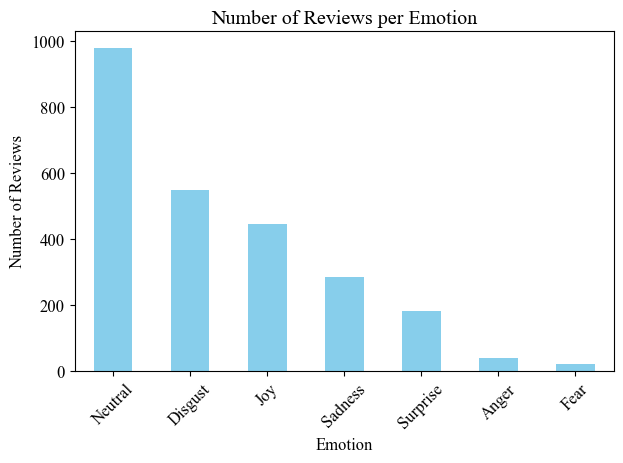

```python
import matplotlib.pyplot as plt

# Count the number of reviews per emotion
emotion_counts = df["Dominant Emotion"].value_counts()

# Plot the bar chart
emotion_counts.plot(kind="bar", color="skyblue")
plt.title("Number of Reviews per Emotion")
plt.xlabel("Emotion")
plt.ylabel("Number of Reviews")
plt.xticks(rotation=45)
plt.tight_layout()
plt.show()
```

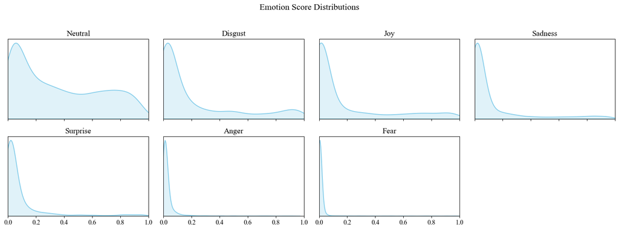

```python
# Define emotion columns
emotion_columns = ["Disgust", "Neutral", "Surprise", "Sadness", "Anger", "Fear", "Joy"]

# Subset and drop NaNs
df_emotions = df[emotion_columns].dropna()

# Sort emotions by mean score
emotions_sorted = df_emotions.mean().sort_values(ascending=False).index.tolist()

# Set up grid layout
n_cols = 4
n_rows = int(np.ceil(len(emotions_sorted) / n_cols))
fig, axes = plt.subplots(n_rows, n_cols, figsize=(16, 3 * n_rows), sharex=True, sharey=False)
axes = axes.flatten()

# Plot each emotion
for i, emotion in enumerate(emotions_sorted):
    sns.kdeplot(data=df_emotions[emotion], ax=axes[i], fill=True, color="skyblue", linewidth=1.5)
    axes[i].set_title(emotion)
    axes[i].set_xlim(0, 1)
    axes[i].set_yticks([])  # Hide y-axis for cleaner look
    axes[i].set_xlabel("")
    axes[i].set_ylabel("")

# Turn off unused axes
for j in range(i + 1, len(axes)):
    axes[j].axis('off')

fig.suptitle("Emotion Score Distributions", fontsize=16)
plt.tight_layout(rect=[0, 0, 1, 0.96])
plt.show()
```

```python
# Sample 10 random rows from mismatches

mismatches = df[
    ((df['Rating'] >= 4) & (df['Sentiment Score'] < 3)) |
    ((df['Rating'] <= 2) & (df['Sentiment Score'] > 4))
]
sampled = mismatches.sample(n=10, random_state=42)

# Iterate over the sampled rows
for _, row in sampled.iterrows():
    print("Review:", row['Review'])
    print("Rating:", row['Rating'])
    print("Sentiment Score:", row['Sentiment Score'])
    print("Emotion:", row['Dominant Emotion'])
    print("-" * 5)
```

```
Review: Save money  and Space!. I have been using this product instead of the biger size in in the cooler at the Store !I am a Senior citizen who has made a purchase of one  box of 6ea .Because of their size I have saved money by using this product and because of that I don't have to waste any of th…
Rating: 5
Sentiment Score: 1
Emotion: Neutral
-----
Review: Big mistake making this an "add on" item. As a diabetic, these are a wonderful "crunchy" snack for me. Very filling and the net carbs per serving are so low I can have them a couple of times a day if I choose. That said, I am EXTREMELY disappointed to find they are now an "add on" item (beca…
Rating: 5
Sentiment Score: 2
Emotion: Disgust
-----
Review: Tastes like bubble gum with a hint of tropical flavor. I have this and the Trident Vibes Tropical Beat (look like giant tic-tacs and come in a shaker bottle) and the taste difference is incredible. These taste like classic bubble gum (yuck) with a hint of tropical flavor, whereas the Tropica…
Rating: 1
Sentiment Score: 5
Emotion: Disgust
-----
Review: Exploded in shipping. Waited awhile for these not shipping fault there was a major ice storm in TX BUT I do not see a place to contact seller as two of the ginger ones ( the ones I really wanted ) exploded in my box
Rating: 4
Sentiment Score: 1
Emotion: Anger
-----
Review: Easy to use. Last year I brined a turkey with a home made brine. Had to boil water and the sugar and salt. Then wait for it to cool. It’s time consuming.This product is more expensive than making your own, but the trade off is no prep. Mix with water and you’re done. No boiling or waiting to…
Rating: 2
Sentiment Score: 5
Emotion: Neutral
-----
Review: Made a beautiful burger out of these. And my dumb brain didn't even realize it was vegetarian.
Rating: 5
Sentiment Score: 1
Emotion: Disgust
-----
Review: Ad and photo did not match.! Checked the ad and saw the photo. Ad did not say "organic", but the photo of the product shows the "organic" label. Hoping it was the "organic" product, but I received the "non- organic" product. Oh well. Maybe the "shopper" did not double check their work, or at…
Rating: 4
Sentiment Score: 1
Emotion: Neutral
-----
Review: Priced doubled in 5 months; quality suffered. I love this tea! A breakfast tea that is not too harsh yet brisk enough to start my day. In July 2022, I ordered a box of 100 teabags that were individually packaged for $9.96. December 2022 I tried to re-order but was surprised to see that the p…
Rating: 4
Sentiment Score: 2
Emotion: Surprise
-----
Review: quantity not what I ordered. The order I placed was for a pack of 6 jars. The box contained only one 13 oz jar.
Rating: 5
Sentiment Score: 1
Emotion: Neutral
-----
Review: Use the right oil. Maybe I didn't use the right oil to fry the fries in.I decided to use my Air Fryer...much better
Rating: 4
Sentiment Score: 2
Emotion: Neutral
-----
```

The analysis reveals several **notable divergences** between **explicit user Ratings**, **model-predicted sentiment polarity**, and **dominant emotion labels**, suggesting complex evaluative and affective dynamics in user-generated reviews.

This comparative analysis demonstrates that **relying solely on sentiment scores or Ratings can obscure the complexity of customer experience**. The integration of **emotion classification reveals latent affective cues**, enabling a more **granular and context-sensitive understanding** of consumer feedback. For applied NLP in review mining, combining these three dimensions—**Rating, sentiment, and emotion**—provides a more robust analytical framework.

### Statistical Significance

A chi-squared test of independence was conducted to assess the association between predicted dominant emotion and sentiment score (on a 1–5 scale). The result was highly significant, indicating that the distribution of dominant emotions varies systematically across different levels of sentiment. The effect size, measured using Cramér’s V, suggests a relatively strong association between the two variables.

This finding implies that the model’s predicted emotional labels are not randomly distributed with respect to sentiment intensity. Instead, certain emotions are more likely to occur in reviews with higher or lower sentiment scores. This supports the construct validity of the emotion classification output and confirms its alignment with more traditional sentiment measures, offering a more nuanced emotional interpretation of customer feedback.

```python
from scipy.stats import chi2_contingency

contingency = pd.crosstab(df["Dominant Emotion"], df["Sentiment Score"])
chi2, p, dof, expected = chi2_contingency(contingency)

print(f"Chi2 = {chi2}, p-value = {p}")
```

```
Chi2 = 1381.44299161655, p-value = 4.587799912358354e-277
```

```python
import pandas as pd
import numpy as np
import scipy.stats as stats

def cramers_v(x, y):
    confusion_matrix = pd.crosstab(x, y)
    chi2 = stats.chi2_contingency(confusion_matrix)[0]
    n = confusion_matrix.sum().sum()
    phi2 = chi2 / n
    r, k = confusion_matrix.shape
    phi2corr = max(0, phi2 - ((k-1)*(r-1))/(n-1))  # bias correction
    rcorr = r - ((r-1)**2)/(n-1)
    kcorr = k - ((k-1)**2)/(n-1)
    return np.sqrt(phi2corr / min((kcorr-1), (rcorr-1)))

cramers_v(df["Dominant Emotion"], df["Sentiment Score"])
```

```
np.float64(0.36872884802891104)
```

### Zero-Shot Classification

```python
from transformers import pipeline
import pandas as pd
import pandas as pd
from wordcloud import WordCloud
import matplotlib.pyplot as plt
```

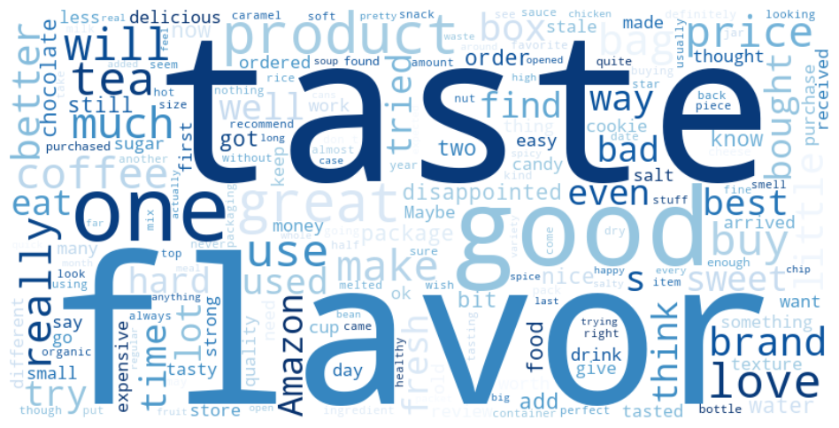

```python
# Combine all reviews into one text
text = " ".join(df['Review'].dropna().astype(str))

# Generate the word cloud
wordcloud = WordCloud(
    width=800,
    height=400,
    background_color='white',
    colormap='Blues'  # try 'Set2', 'cool', 'Dark2', etc.
).generate(text)

# Display the word cloud
plt.figure(figsize=(10, 5))
plt.imshow(wordcloud, interpolation='bilinear')
plt.axis("off")
plt.tight_layout()
plt.show()
```

```python
# Your candidate labels
candidate_labels = ['Packaging', 'Price', 'Value for Money', 'Taste and Flavour', 'Freshness', 'Expiration Date', 'Delivery', 'Ingredients', 'Quality', 'Size and Quantity', 'Easy to Use', 'Not as Expected', 'Returns', 'Damaged']
# Load the zero-shot classifier
classifier = pipeline("zero-shot-classification", model="facebook/bart-large-mnli")


# Function to classify a single piece of text and return a dict of scores
def classify_review(text):
    result = classifier(text, candidate_labels, multi_label=True)
    return {label: score for label, score in zip(result['labels'], result['scores'])}

# Apply the classification to each review
scores_df = df['Review'].apply(classify_review).apply(pd.Series)

# Concatenate the original df with the scores
df = pd.concat([df, scores_df], axis=1)

# Find dominant topic and its score
dominant_topic = scores_df.idxmax(axis=1)
dominant_score = scores_df.max(axis=1)

# Apply threshold: if score < threshold, assign 'No dominant topic'
df['Dominant Topic'] = dominant_topic.where(dominant_score >= 0.5, 'Other')
```

```
Device set to use mps:0
```

```python
df.head()
```

|  | Rating | Parent Asin | Main Category | Product Title | Retailer | Review | Word Count | Sentence Count | Sentiment Score | Disgust | ... | Freshness | Price | Packaging | Quality | Delivery | Ingredients | Value for Money | Expiration Date | Easy to Use | Dominant Topic |
| --- | --- | --- | --- | --- | --- | --- | --- | --- | --- | --- | --- | --- | --- | --- | --- | --- | --- | --- | --- | --- | --- |
| 0 | 1 | B0BR5N8Y3M | Grocery | Gumballs for Gumball Machine - 1 Inch Large Gu... | Global Gumball | What the ? I normally am happy with this produ... | 66 | 4 | 2 | 0.804613 | ... | 0.563067 | 0.512632 | 0.504350 | 0.479996 | 0.443529 | 0.398306 | 0.274983 | 0.262287 | 0.003500 | Not as Expected |
| 1 | 1 | B00I8GLPSO | Grocery | Stove Top Stuffing Mix, Chicken, 12 Ounce Box | Stove Top | It can often be purchased for less money at an... | 36 | 2 | 2 | 0.016087 | ... | 0.656657 | 0.761610 | 0.890504 | 0.599424 | 0.631338 | 0.496917 | 0.873846 | 0.421396 | 0.711866 | Not as Expected |
| 2 | 1 | B000JMFCXO | Grocery | Almonds Whole Natural 2lb (32 Ounces) | Spicy World | Inedible outrage. Lots of variability w/ this ... | 67 | 10 | 1 | 0.055551 | ... | 0.453949 | 0.630233 | 0.970938 | 0.138929 | 0.451631 | 0.424056 | 0.021255 | 0.109231 | 0.003598 | Damaged |
| 3 | 1 | B0C4FMN1QK | Grocery | Knorr Pasta Sides For Delicious Quick Pasta Si... | Knorr | Cheap and easy. These are cheap and easy side ... | 27 | 4 | 2 | 0.019381 | ... | 0.110738 | 0.486595 | 0.007563 | 0.010856 | 0.128732 | 0.222780 | 0.553957 | 0.076687 | 0.554640 | Not as Expected |
| 4 | 1 | B00ICT8RQU | Grocery | Trader Joe's Instant Coffee Packets with Cream... | TJ's | Two thumbs down. Not impressed, still needed t... | 17 | 3 | 2 | 0.146017 | ... | 0.549498 | 0.553083 | 0.255709 | 0.029213 | 0.489212 | 0.707407 | 0.124269 | 0.232694 | 0.000550 | Not as Expected |

5 rows × 32 columns

```python
df.to_csv("reviews_final.csv", index=False)
```

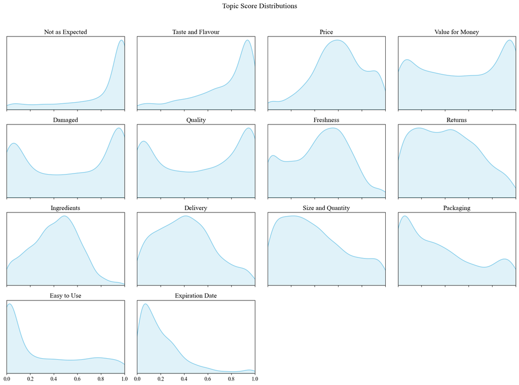

```python
# Define emotion columns
topic_columns = ['Packaging', 'Price', 'Value for Money', 'Taste and Flavour',
    'Freshness', 'Expiration Date', 'Delivery', 'Ingredients', 'Quality',
    'Size and Quantity', 'Easy to Use', 'Not as Expected', 'Returns', 'Damaged'
]

# Subset and drop NaNs
df_topics = df[topic_columns].dropna()

# Sort emotions by mean score
topics_sorted = df_topics.mean().sort_values(ascending=False).index.tolist()

# Set up grid layout
n_cols = 4
n_rows = int(np.ceil(len(topics_sorted) / n_cols))
fig, axes = plt.subplots(n_rows, n_cols, figsize=(16, 3 * n_rows), sharex=True, sharey=False)
axes = axes.flatten()

# Plot each emotion
for i, topic in enumerate(topics_sorted):
    sns.kdeplot(data=df_topics[topic], ax=axes[i], fill=True, color="skyblue", linewidth=1.5)
    axes[i].set_title(topic)
    axes[i].set_xlim(0, 1)
    axes[i].set_yticks([])  # Hide y-axis for cleaner look
    axes[i].set_xlabel("")
    axes[i].set_ylabel("")

# Turn off unused axes
for j in range(i + 1, len(axes)):
    axes[j].axis('off')

fig.suptitle("Topic Score Distributions", fontsize=16)
plt.tight_layout(rect=[0, 0, 1, 0.96])
plt.show()
```